# Milestone Report

12/11/2020

# Overview

In this capstone project will be applying data science in the area of natural language processing (NLP).

The milestone report describes exploratory data analysis performed with the course data set.

The data is from a corpus called HC Corpora and it contains texts collected from blogs, twitter and newsr: https://d396qusza40orc.cloudfront.net/dsscapstone/dataset/Coursera-SwiftKey.zip

# Exploratory Data Analysis

The summary of the data files is shown below

```r
# summarize information about the data files
summary_DT <- data.frame(filename = c("en_US.blogs.txt","en_US.news.txt","en_US.twitter.txt"),
                         size = c(format(object.size(DT_blog), units = "auto"),
                                  format(object.size(DT_news), units = "auto"),
                                  format(object.size(DT_twitter), units = "auto")),
                         lines = c(length(DT_blog),length(DT_news),length(DT_twitter)))
# summary table
summary_DT %>%
  kable("html") %>%
  kable_styling()
```

| filename | size | lines |
| --- | --- | --- |
| en_US.blogs.txt | 255.4 Mb | 899288 |
| en_US.news.txt | 19.8 Mb | 77259 |
| en_US.twitter.txt | 319 Mb | 2360148 |

# Creating the sample data set

To avoid performance problems, a random sampling of the data set was performed

# Cleaning and preprocessing

To create a corpus and then we perform following steps to clean and simplify the data:

- Makes all character in lower case.
- Removes numbers.
- Removes punctuation.
- Removes extra whitespaces.
- Removes Non-ASCII characters.
- Remove stop words.
- Perform stemming
- Remove profanity words

```r
corpus <- VCorpus(VectorSource(text_sample))
toSpace <- content_transformer(function(x, pattern) gsub(pattern, " ", x))
corpus <- tm_map(corpus, toSpace, "(f|ht)tp(s?)://(.*)[.][a-z]+")
corpus <- tm_map(corpus, toSpace, "@[^\\s]+")
corpus <- tm_map(corpus, tolower)
corpus <- tm_map(corpus, removeWords, stopwords("en"))
corpus <- tm_map(corpus, removePunctuation)
corpus <- tm_map(corpus, removeNumbers)
corpus <- tm_map(corpus, stripWhitespace)
corpus <- tm_map(corpus, PlainTextDocument)
```

# Tokenization

Tokenization to break sentences and phrases in to pairs of words or n-grams. Essentially breaking down units of words or tokens, hence the term tokenization.

N-grams are used to understand relationships between words, they define how often word A is followed by word B.

- Unigrams are single words.
- Bigrams are two words combinations.
- Trigrams are three-word combinations.

## Unigrams

```
##       word1 freq
## 11040   get 2545
## 14866  just 2507
## 16161  like 2397
## 20135   one 2297
## 31585  will 2290
## 13588    im 2219
```

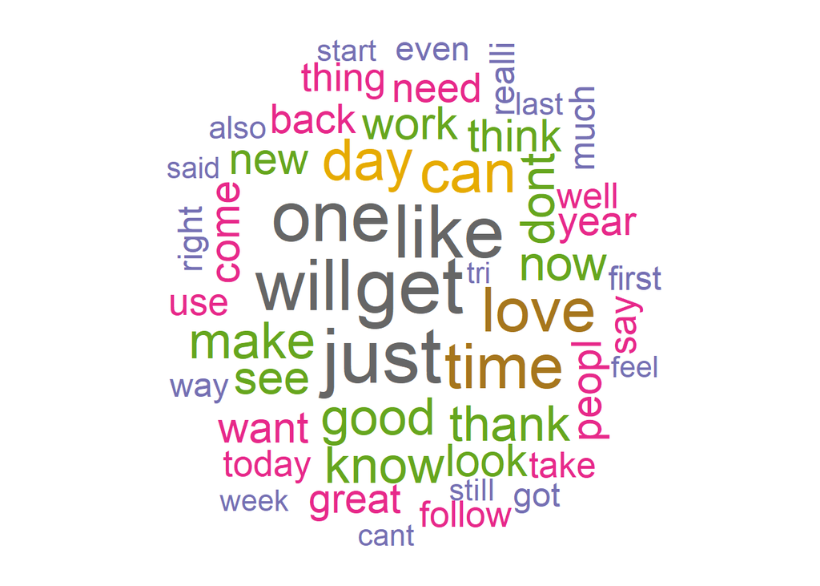

```r
wordcloud(sampleCorpus, max.words = 50, random.order = FALSE, colors=brewer.pal(8,"Dark2"))
```

## Bigrams

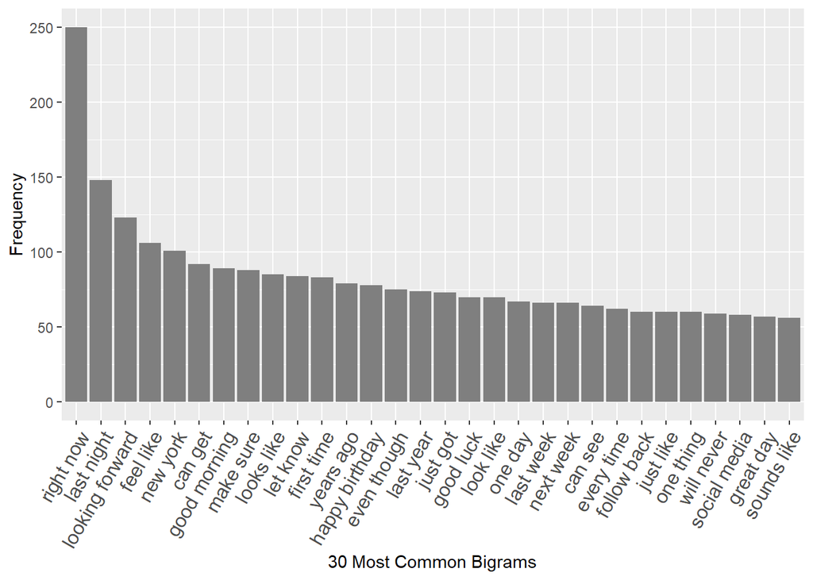

```r
makePlot(freq2, "30 Most Common Bigrams")
```

## Trigrams

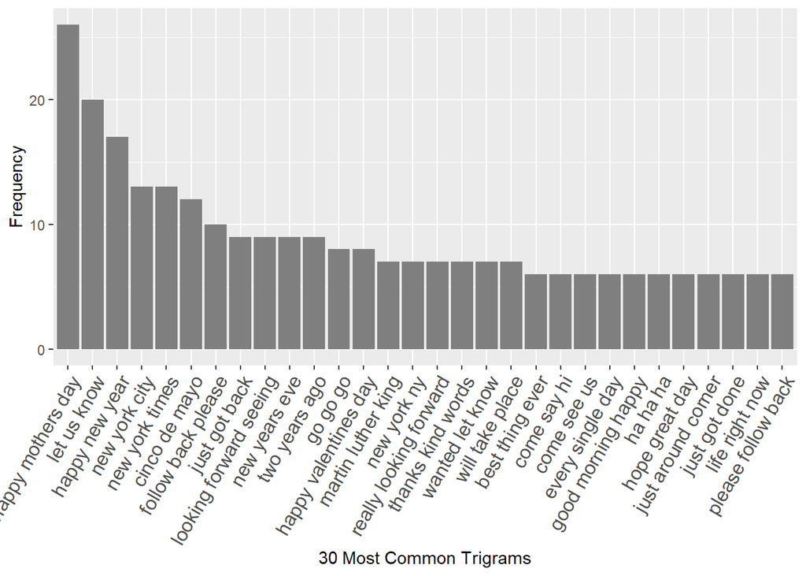

```r
makePlot(freq3, "30 Most Common Trigrams")
```

# Next

I do exploratory analysis initially. The next steps of this capstone project would be to finalize our predictive algorithm, and deploy our algorithm using shiny() app. As for the Shiny app it will consist of a simple user interface that will allow a user to enter text into a single textbox.